# Principal component analysis

Michael C. Jeziorski

23 Oct 2024

Principal component analysis (PCA) applies a mathematical transformation to a dataset with the intention of accounting for as much of the variation in the data as possible using a reduced number of dimensions, or principal components. The first principal component is a dimension that accounts for a maximal portion of the total variation in the dataset, and each successive principal component accounts for a maximal part of the remaining variation while being uncorrelated with (orthogonal to) previous components.

The goal of PCA is to take variables that are likely correlated with each other and transform them into uncorrelated dimensions. To accomplish this, each variable is centered (mean made equivalent to 0) and scaled (variance made equivalent to 1) so that each is weighted the same. Matrix algebra is then applied to identify the principal components. If the dataset has n variables, then n principal components will be generated. However, the benefit of PCA is that, because each component in turn is accounting for a maximal fraction of the remaining variance, the first L components can explain much more variation in the data than any L of the original variables do.

The source of the data we will use is the Wisconsin Breast Cancer dataset from the UCI Machine Learning repository. The following code chunk will read in the data and assign the correct column names.

```r
# using the Wisconsin Breast Cancer dataset from the UCI Machine learning repository
wdbc <- read_csv("https://archive.ics.uci.edu/ml/machine-learning-databases/breast-cancer-wisconsin/wdbc.data",
                 col_names = FALSE, show_col_types = FALSE)

# The file comes without colume names, we will use features and qualifications.
features <- c("radius", "texture", "perimeter", "area", "smoothness", "compactness", "concavity",
              "concave_points", "symmetry", "fractal_dimension")
names(wdbc) <- c("id", "diagnosis", paste0(features,"_mean"), paste0(features,"_se"),
                 paste0(features,"_worst"))
```

```r
# The data is used at Mike's PCA example.
# We will try the factor analysis subroutines with psych package

# Now for selection only the data without the ID and group
wdbc_all <- wdbc %>% select(-1, -2)
wdbc_mean <- wdbc_all %>% select(radius_mean:fractal_dimension_mean)
```

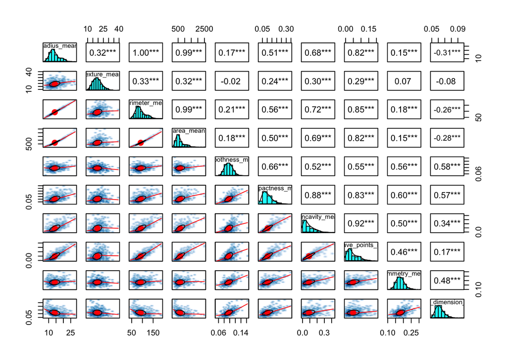

```r
wdbc_scale <- scale(wdbc_all)

# First look at the variables in a correlation matrix
# wdbc_mean %>%
#  select(radius_mean:fractal_dimension_mean) %>%
#  plot()
pairs.panels(wdbc_mean, pch = 21, stars = TRUE,  smoother = TRUE)
```

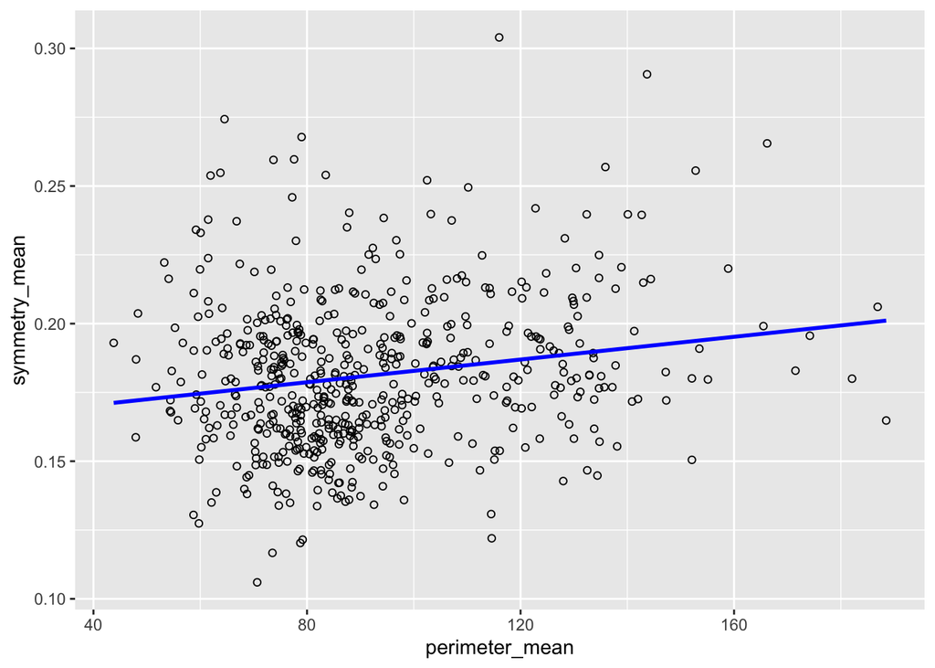

```r
wdbc %>%
  ggplot(aes(x = perimeter_mean, y = symmetry_mean)) +
  geom_point(pch = 1) +
  geom_smooth(method = "lm", color = "blue", se = FALSE)
```

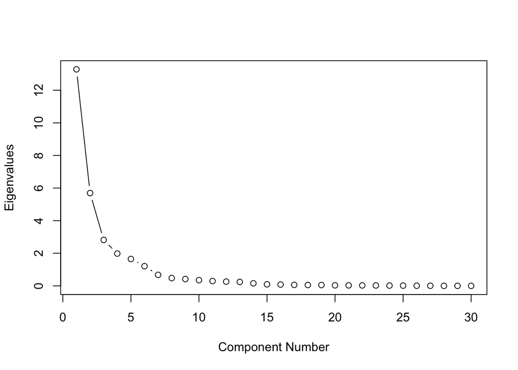

```r
# starting with latent variable exploratory factor analysis (EFA)
# the PCS for all
# principal(wdbc_all, 30, rotate = "none", scores = TRUE, cor = "cor", method = "regression")

pca_wdbc <- principal(wdbc_scale, 30, rotate = "varimax", scores = TRUE, use ="pairwise", cor = "cor", covar = TRUE, method = "regression")
plot(pca_wdbc$values, type = "b", ylab = "Eigenvalues", xlab = "Component Number")

scores_pca_wdbc <- pca_wdbc$scores
text(scores_pca_wdbc[,1], scores_pca_wdbc[,2], labels=rownames(scores_pca_wdbc), cex=0.7)
```

Both `principal()` and `fa()` are functions from the `psych` package that generate a principal component analysis and a factor analisis on the data; we will use `principal()` with the subset of the dataframe. We will choose four factors. A summary of the results can be viewed using `summary()`.

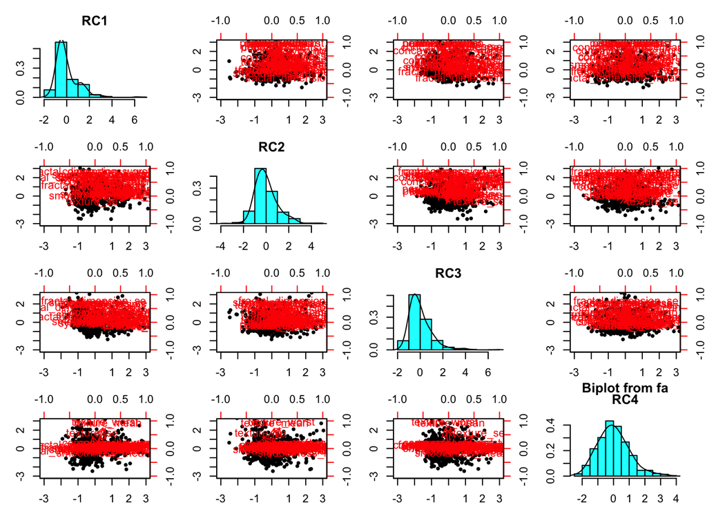

```r
pca_wdbc_4c <- principal(wdbc_scale, 4, rotate = "varimax", scores = TRUE, cor = "cor", method = "regression")
biplot(pca_wdbc_4c)
```

```r
pca_wdbc_4c
```

```
## Principal Components Analysis
## Call: principal(r = wdbc_scale, nfactors = 4, rotate = "varimax", scores = TRUE,
##     method = "regression", cor = "cor")
## Standardized loadings (pattern matrix) based upon correlation matrix
##                           RC1   RC2   RC3   RC4   h2    u2 com
## radius_mean              0.95  0.12 -0.13  0.10 0.95 0.049 1.1
## texture_mean             0.25  0.06  0.05  0.91 0.90 0.105 1.2
## perimeter_mean           0.95  0.17 -0.10  0.10 0.95 0.045 1.1
## area_mean                0.97  0.09 -0.08  0.09 0.96 0.039 1.0
## smoothness_mean          0.16  0.65  0.26 -0.19 0.55 0.452 1.6
## compactness_mean         0.46  0.76  0.33  0.05 0.91 0.091 2.1
## concavity_mean           0.66  0.60  0.32  0.11 0.91 0.092 2.5
## concave_points_mean      0.80  0.50  0.16  0.05 0.92 0.079 1.8
## symmetry_mean            0.14  0.58  0.34 -0.05 0.47 0.527 1.8
## fractal_dimension_mean  -0.31  0.66  0.54 -0.09 0.83 0.174 2.4
## radius_se                0.83 -0.01  0.40  0.03 0.85 0.151 1.4
## texture_se              -0.06 -0.22  0.60  0.54 0.70 0.298 2.3
## perimeter_se             0.82  0.03  0.42  0.04 0.85 0.145 1.5
## area_se                  0.87 -0.02  0.26  0.01 0.83 0.167 1.2
## smoothness_se           -0.14  0.00  0.70 -0.05 0.51 0.487 1.1
## compactness_se           0.21  0.51  0.67  0.11 0.76 0.237 2.1
## concavity_se             0.22  0.40  0.64  0.07 0.62 0.378 2.0
## concave_points_se        0.43  0.32  0.64  0.00 0.70 0.303 2.3
## symmetry_se             -0.04  0.05  0.67 -0.03 0.45 0.545 1.0
## fractal_dimension_se    -0.03  0.38  0.75  0.02 0.71 0.287 1.5
## radius_worst             0.94  0.20 -0.16  0.13 0.97 0.028 1.2
## texture_worst            0.20  0.19 -0.07  0.94 0.95 0.045 1.2
## perimeter_worst          0.94  0.25 -0.13  0.14 0.98 0.022 1.2
## area_worst               0.95  0.16 -0.11  0.12 0.95 0.053 1.1
## smoothness_worst         0.06  0.76  0.01 -0.01 0.58 0.423 1.0
## compactness_worst        0.32  0.86  0.07  0.19 0.88 0.123 1.4
## concavity_worst          0.46  0.77  0.11  0.19 0.84 0.155 1.8
## concave_points_worst     0.68  0.66 -0.01  0.11 0.92 0.082 2.1
## symmetry_worst           0.07  0.72 -0.05  0.06 0.53 0.475 1.0
## fractal_dimension_worst -0.08  0.88  0.19  0.11 0.83 0.173 1.1
##
##                         RC1  RC2  RC3  RC4
## SS loadings           10.19 6.93 4.40 2.26
## Proportion Var         0.34 0.23 0.15 0.08
## Cumulative Var         0.34 0.57 0.72 0.79
## Proportion Explained   0.43 0.29 0.19 0.09
## Cumulative Proportion  0.43 0.72 0.91 1.00
##
## Mean item complexity =  1.5
## Test of the hypothesis that 4 components are sufficient.
##
## The root mean square of the residuals (RMSR) is  0.06
##  with the empirical chi square  1886.57  with prob <  2e-219
##
## Fit based upon off diagonal values = 0.98
```

```r
summary(pca_wdbc_4c)
```

```
##
## Factor analysis with Call: principal(r = wdbc_scale, nfactors = 4, rotate = "varimax", scores = TRUE,
##     method = "regression", cor = "cor")
##
## Test of the hypothesis that 4 factors are sufficient.
## The degrees of freedom for the model is 321  and the objective function was  27.96
## The number of observations was  569  with Chi Square =  15506.2  with prob <  0
##
## The root mean square of the residuals (RMSA) is  0.06
```

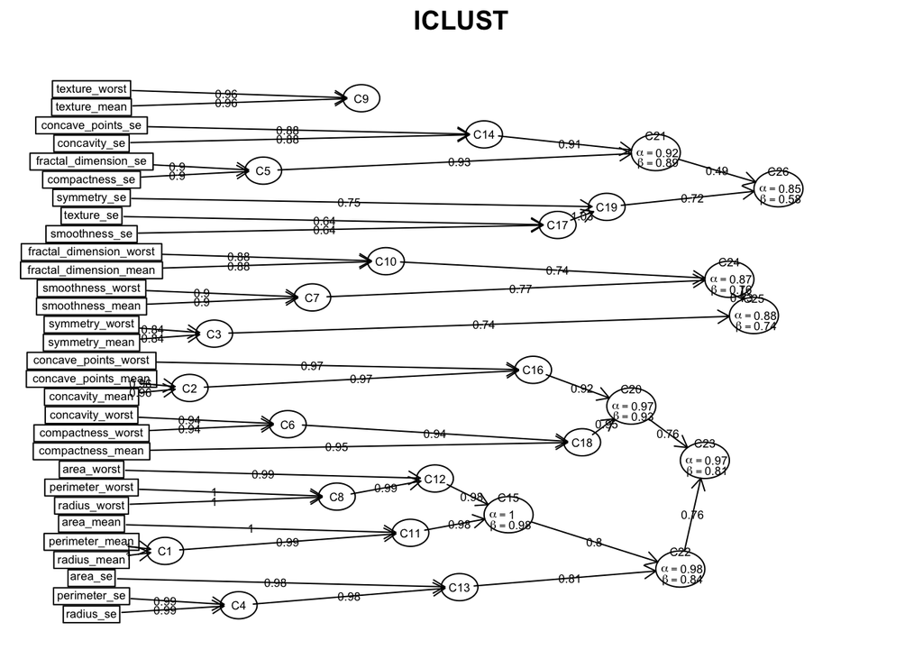

```
## ICLUST (Item Cluster Analysis)
## Call: iclust(r.mat = wdbc_scale, nclusters = 4)
##
## Purified Alpha:
##  C23  C25  C26   C9
## 0.98 0.92 0.85 0.95
##
## G6* reliability:
## C23 C25 C26  C9
##   1   1   1   1
##
## Original Beta:
##  C23  C25  C26   C9
## 0.81 0.74 0.58 0.95
##
## Cluster size:
## C23 C25 C26  C9
##  12   9   7   2
##
## Item by Cluster Structure matrix:
##                           O   P   C23   C25   C26    C9
## radius_mean             C23 C23  0.93  0.19  0.06  0.32
## texture_mean             C9 C23  0.35  0.13  0.19  0.95
## perimeter_mean          C23 C23  0.95  0.24  0.10  0.33
## area_mean               C23 C23  0.94  0.19  0.09  0.32
## smoothness_mean         C25 C23  0.35  0.77  0.37  0.01
## compactness_mean        C23 C23  0.70  0.87  0.58  0.25
## concavity_mean          C23 C23  0.85  0.70  0.57  0.31
## concave_points_mean     C23 C23  0.93  0.62  0.39  0.31
## symmetry_mean           C25 C23  0.32  0.71  0.45  0.08
## fractal_dimension_mean  C25 C23 -0.05  0.74  0.59 -0.07
## radius_se               C23 C23  0.82  0.27  0.41  0.25
## texture_se              C26 C23 -0.01  0.01  0.50  0.41
## perimeter_se            C23 C25  0.82  0.30  0.45  0.25
## area_se                 C23 C25  0.84  0.21  0.29  0.24
## smoothness_se           C26 C25 -0.08  0.21  0.59 -0.04
## compactness_se          C26 C25  0.41  0.61  0.85  0.17
## concavity_se            C26 C25  0.39  0.46  0.81  0.13
## concave_points_se       C26 C25  0.54  0.46  0.79  0.13
## symmetry_se             C26 C25  0.03  0.28  0.61 -0.04
```

[output cut: 11 more lines]

```
##
## With Sums of squares of:
##  C23  C25  C26   C9
## 11.0  5.8  4.2  2.1
##
## Purified scale intercorrelations
##  reliabilities on diagonal
##  correlations corrected for attenuation above diagonal:
##      C23  C25  C26   C9
## C23 0.98 0.46 0.29 0.35
## C25 0.44 0.92 0.56 0.22
## C26 0.26 0.50 0.85 0.17
## C9  0.34 0.20 0.16 0.95
##
## Cluster fit =  0.84   Pattern fit =  0.98  RMSR =  0.07
```

```r
iclust(wdbc_scale, nclusters = 4)
```

```r
#
fa_wdbc_4c <- fa(wdbc_scale, 4, rotate="varimax", fm="ml", oblique.scores=TRUE)
fa_wdbc_4c
```

```
## Factor Analysis using method =  ml
## Call: fa(r = wdbc_scale, nfactors = 4, rotate = "varimax", fm = "ml",
##     oblique.scores = TRUE)
## Standardized loadings (pattern matrix) based upon correlation matrix
##                           ML1   ML4   ML3   ML2   h2     u2 com
## radius_mean              0.97  0.11 -0.19  0.05 1.00 0.0033 1.1
## texture_mean             0.26  0.10 -0.05  0.88 0.85 0.1511 1.2
## perimeter_mean           0.97  0.16 -0.17  0.05 1.00 0.0035 1.1
## area_mean                0.98  0.09 -0.11  0.06 0.99 0.0145 1.0
## smoothness_mean          0.15  0.63  0.21 -0.08 0.47 0.5326 1.4
## compactness_mean         0.44  0.85  0.11  0.03 0.93 0.0700 1.6
## concavity_mean           0.63  0.70  0.10  0.07 0.91 0.0925 2.0
## concave_points_mean      0.79  0.55  0.03  0.04 0.92 0.0752 1.8
## symmetry_mean            0.13  0.58  0.24  0.00 0.41 0.5925 1.5
## fractal_dimension_mean  -0.33  0.75  0.36 -0.06 0.81 0.1925 1.9
## radius_se                0.80  0.09  0.57  0.10 0.98 0.0168 1.9
## texture_se              -0.06 -0.01  0.38  0.50 0.40 0.6023 1.9
## perimeter_se             0.78  0.15  0.56  0.10 0.96 0.0361 1.9
## area_se                  0.84  0.04  0.46  0.08 0.93 0.0657 1.6
## smoothness_se           -0.16  0.17  0.48  0.00 0.29 0.7118 1.5
## compactness_se           0.18  0.72  0.28  0.02 0.62 0.3778 1.4
## concavity_se             0.17  0.61  0.25  0.00 0.46 0.5379 1.5
## concave_points_se        0.38  0.53  0.30 -0.04 0.52 0.4810 2.5
## symmetry_se             -0.04  0.20  0.47 -0.04 0.26 0.7384 1.4
## fractal_dimension_se    -0.04  0.59  0.38 -0.04 0.49 0.5130 1.7
## radius_worst             0.95  0.16 -0.13  0.12 0.96 0.0415 1.1
## texture_worst            0.21  0.17 -0.14  0.95 1.00 0.0049 1.2
## perimeter_worst          0.94  0.22 -0.12  0.12 0.96 0.0371 1.2
## area_worst               0.94  0.13 -0.05  0.13 0.92 0.0750 1.1
## smoothness_worst         0.06  0.64  0.02  0.11 0.43 0.5721 1.1
## compactness_worst        0.31  0.85 -0.09  0.15 0.85 0.1533 1.3
## concavity_worst          0.43  0.79 -0.09  0.14 0.84 0.1629 1.6
## concave_points_worst     0.66  0.65 -0.13  0.10 0.89 0.1125 2.1
## symmetry_worst           0.08  0.58 -0.08  0.11 0.36 0.6381 1.2
## fractal_dimension_worst -0.09  0.86  0.04  0.10 0.76 0.2366 1.1
##
##                        ML1  ML4  ML3  ML2
## SS loadings           9.93 7.86 2.26 2.11
## Proportion Var        0.33 0.26 0.08 0.07
## Cumulative Var        0.33 0.59 0.67 0.74
```

[output cut: 9 more lines]

```
## The root mean square of the residuals (RMSR) is  0.07
## The df corrected root mean square of the residuals is  0.08
##
## The harmonic n.obs is  569 with the empirical chi square  2577.09  with prob <  0
## The total n.obs was  569  with Likelihood Chi Square =  13727.21  with prob <  0
##
## Tucker Lewis Index of factoring reliability =  0.531
## RMSEA index =  0.271  and the 90 % confidence intervals are  0.267 0.275
## BIC =  11690.82
## Fit based upon off diagonal values = 0.98
## Measures of factor score adequacy
##                                                    ML1  ML4  ML3  ML2
## Correlation of (regression) scores with factors   1.00 0.99 0.99 1.00
## Multiple R square of scores with factors          1.00 0.97 0.98 0.99
## Minimum correlation of possible factor scores     0.99 0.95 0.96 0.99
```

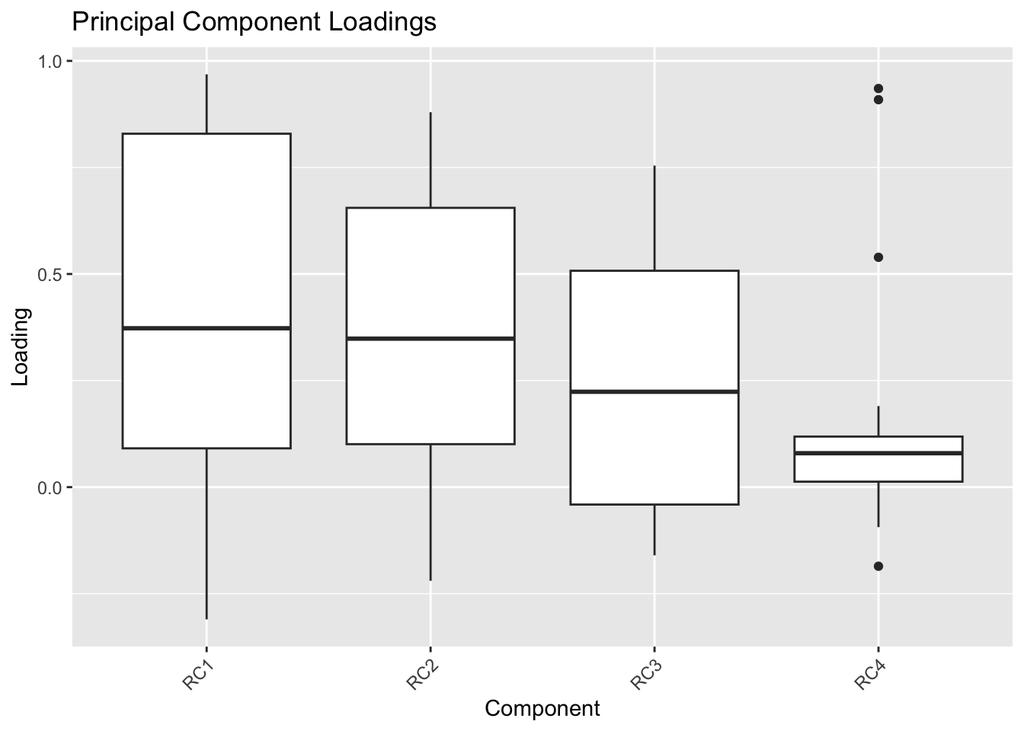

```r
pca_wdbc_4c_loadings_df <- as_tibble(pca_wdbc_4c$loadings[])
pca_wdbc_4c_loadings_df$variable <- rownames(pca_wdbc_4c_loadings_df)
pca_wdbc_4c_loadings_long <- pivot_longer(pca_wdbc_4c_loadings_df, -variable, names_to = "component", values_to = "loading")
# boxplot(loading~component, data=pca_wdbc_4c_loadings_long)

ggplot(pca_wdbc_4c_loadings_long, aes(x = component, y = loading)) +
  geom_boxplot() +
  theme(axis.text.x = element_text(angle = 45, hjust = 1)) +
  labs(title = "Principal Component Loadings", x = "Component", y = "Loading")
```